Skip to contents

# 🎓 Tutorial: the Northeast Pacific (FAO area 67) from zero to a report

Source: [`vignettes/articles/tutorial-67.Rmd`](https://github.com/Linbojun99/faofishingreport/blob/main/vignettes/articles/tutorial-67.Rmd)

📦 **Data**: [FAO Global Capture Production](https://www.fao.org/fishery/collection/capture/en), release **2026.1.0** (published by FAO on 2026-03-30; catches 1950–2024), downloaded from Capture_2026.1.0.zip. Licence [CC BY 4.0](https://creativecommons.org/licenses/by/4.0/). `fao_data_info()` shows the release you use and how to cite it.

This tutorial walks through a complete assessment of one FAO major fishing area, the **Northeast Pacific (FAO area 67)**, from an empty R session to a finished report. Area 67 stretches from the eastern Bering Sea and the Gulf of Alaska along the coasts of Canada and the United States down to northern California (40° N). The tutorial uses almost every function of the package, in the order you would use them in your own work, and explains **what each chart shows, how to read it and what it says about the area**. If you have never used the package, read it from top to bottom and run the code as you go; if you know the package, use the table of contents to jump to the step you need.

Area 67 is a good teaching example because its history is written clearly in the data: for twenty years the fleets of Japan and the USSR took a large part of its catch, until the United States and Canada extended their fishery limits to 200 nautical miles in 1977 and the catch passed to their own fleets. It is dominated by one species, the Alaska pollock, it holds a famous case of overfishing (the Pacific ocean perch) and the salmon fisheries of the North Pacific, and its data are among the best of all FAO areas. Every number in the text below is computed from the data when the page is built, so it matches the charts.

| Step | What you do | Functions |
| --- | --- | --- |
| 1 | Prepare R, a project folder and the settings | `fao_settings()`, `fao_font()` |
| 2 | Get the FAO data, know its version, save your own copy | `check_fao_update()`, `download_fao_data()`, `load_fao_data()`, `fao_data_info()` |
| 3 | The catch of the area: trend, stages, share of the world | `fishing_area_data()` |
| 4 | The main species | `fishing_area_species()` |
| 5 | The main countries | `fishing_area_country()` |
| 6 | One species, one country | `species_country()`, `country_species()`, `country_analysis()` |
| 7 | Composition, stock status, trends and shifts | `species_group_composition()`, `stock_status()`, `peak_trend()`, `regime_shift()`, `area_overview()` |
| 8 | Data quality, diversity and fleets | `data_quality()`, `diversity_concentration()`, `country_group_summary()`, `coastal_distant()` |
| 9 | Methods from the literature | `catch_shocks()`, `collapse_analysis()`, `catch_synchrony()`, `pelagic_demersal()`, `distant_water_profile()` |
| 10 | Species traits and temperature | `fishbase_match()`, `fao_area_sst()`, `mean_temperature_catch()` |
| 11 | Stock assessment of the main species | `cmsy_setup()`, `cmsy_area()` |
| 12 | The report in Word, LaTeX and PDF (with TinyTeX) | `fao_report()`, `tinytex::install_tinytex()` |
| 13 | Where everything is saved and how to get it back |  |

**How the charts are explained.** Under each chart, “🔎 How to read it” describes the axes, colours and lines, and “What it shows for area 67” gives the result. Charts describe the **reported catch**: they say what was landed and reported to FAO, not how many fish are in the sea. Keep that in mind for every conclusion.

## 1. 🧰 Prepare

Install the package once, with all the packages it uses (see 🚀 Get started for details), then load it at the start of every session:

```r
install.packages("remotes")
remotes::install_github("Linbojun99/faofishingreport", dependencies = TRUE)
```

```r
library(faofishingreport)
```

**Work in a project folder.** Every function saves its charts and tables in the *working directory* (the folder `getwd()` returns). Create one folder per assessment, e.g. with an RStudio project, or set it yourself:

```r
dir.create("~/fao67", showWarnings = FALSE)
setwd("~/fao67")
getwd()
```

**Choose the settings once for the session** with `fao_settings()`: the language of the charts, their style and the output formats. Call it without arguments to see the current settings.

```r
fao_settings(lang = "en", theme = "classic", dpi = 100, pptx = FALSE)
```

| Setting | Here | What it does |
| --- | --- | --- |
| `lang` | `"en"` | Chart text and names in English; `"zh"` Chinese; `"both"` both |
| `theme` | `"classic"` | Chart style (see 🎨 Customise) |
| `dpi` | `100` | Resolution of the PNG files (300 for print) |
| `pptx` | `FALSE` | `TRUE` also saves every chart as an editable PowerPoint file |

The chart font is chosen for your system (`fao_font()` shows it): SimSun on Windows, Songti SC on macOS, Noto Serif CJK SC on Linux, so that Chinese names display.

## 2. 💾 Get the data

### 2.1 Check for the newest FAO release

FAO publishes the Global Capture Production statistics once a year. The package comes with a recent release; `check_fao_update()` compares it with the newest one online, and `download_fao_data()` downloads and converts a release (about 6 MB, usually under a minute):

```r
check_fao_update()     # newest release online vs. the data on your computer
download_fao_data()    # download the newest release (only when FAO publishes a new one)
```

### 2.2 Load the data and know which release you use

`load_fao_data()` returns the newest release available on your computer (downloaded, or else the one bundled with the package), one row per country, species item, area and year:

```r
fao <- load_fao_data()
dim(fao)
```

```
#> [1] 1024698       8
```

```r
show_table(fao[fao$FAO.major.fishing.area..Name. == "Pacific, Northeast" & fao$Year == 2024, ], n = 5)
```

|  | Country..Name. | ASFIS.species..Name. | FAO.major.fishing.area..Name. | Unit..Name. | Unit | Year | Production | Production.Type |
| --- | --- | --- | --- | --- | --- | --- | --- | --- |
| 95717 | Canada | Pink(=Humpback) salmon | Pacific, Northeast | Tonnes - live weight | TLW, Number | 2024 | 3,659.42 | actual |
| 95792 | Canada | Chum(=Keta=Dog) salmon | Pacific, Northeast | Tonnes - live weight | TLW, Number | 2024 | 1,840.59 | actual |
| 95867 | Canada | Coho(=Silver) salmon | Pacific, Northeast | Tonnes - live weight | TLW, Number | 2024 | 432.38 | actual |
| 95908 | Canada | Rainbow trout | Pacific, Northeast | Tonnes - live weight | TLW, Number | 2024 | 0.00 | actual |
| 95983 | Canada | Sockeye(=Red) salmon | Pacific, Northeast | Tonnes - live weight | TLW, Number | 2024 | 1,418.83 | actual |

| Column | Meaning |
| --- | --- |
| `Country..Name.` | Reporting country (FAO English name) |
| `ASFIS.species..Name.` | FAO species item (a species, a genus, a family or a group such as “Marine fishes nei”, *nei* = not elsewhere included) |
| `FAO.major.fishing.area..Name.` | FAO major fishing area |
| `Year`, `Production` | Year and catch in tonnes live weight |
| `Production.Type` | How the value was obtained: reported by the country, estimated by FAO, … |

**Always record the release you used**: FAO revises past years in every release, so a report must say which one it is based on. `fao_data_info()` gives the release, its dates, the download link and a citation:

```r
info <- fao_data_info()
info
```

```
#> FAO Global Capture Production
#>   Release:   2026.1.0 (published by FAO on 2026-03-30)
#>   Years:     1950-2024
#>   File:      https://www.fao.org/fishery/static/Data/Capture_2026.1.0.zip
#>   Obtained:  bundled with faofishingreport, downloaded from FAO on 2026-10-10
#>   Licence:   CC BY 4.0 (https://www.fao.org/contact-us/terms/db-terms-of-use/en)
#>   Citation:  FAO. 2026. Global Capture Production 1950-2024, release 2026.1.0. In: Fisheries and Aquaculture [online]. Rome. [Cited 10 October 2026]. https://www.fao.org/fishery/collection/capture/en. Licence: CC BY 4.0.
```

### 2.3 Where the data are kept

Downloaded releases are kept in the data folder of the package, `fao_data_dir()`, and used again in every session. To share one folder between computers or a team, set the environment variable `FAOFISHINGREPORT_DATA_DIR` in `~/.Renviron` (see 💾 FAO data). Your own copies of the data of an area can be saved like any R object:

```r
fao_data_dir()
```

```
#> [1] "/home/runner/.local/share/R/faofishingreport"
```

```r
area67_raw <- fao[fao$FAO.major.fishing.area..Name. == "Pacific, Northeast", ]
saveRDS(area67_raw, "area67_data.rds")                 # for R: readRDS("area67_data.rds")
write.csv(area67_raw, "area67_data.csv", row.names = FALSE, fileEncoding = "UTF-8")   # for Excel
```

## 3. 🌊 The catch of the area

`fishing_area_data()` takes the name of an FAO major area, keeps its data, and draws the total catch with its stages and the share of the area in the world marine catch:

```r
NEP <- fishing_area_data("Pacific, Northeast")
area67 <- NEP$area_data
```

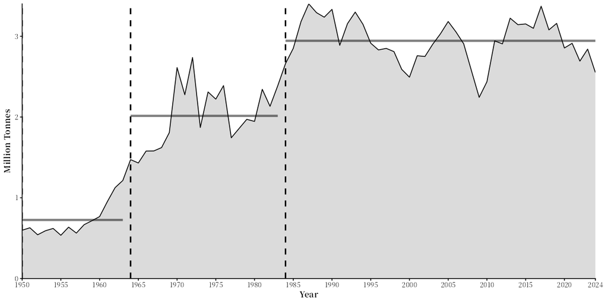

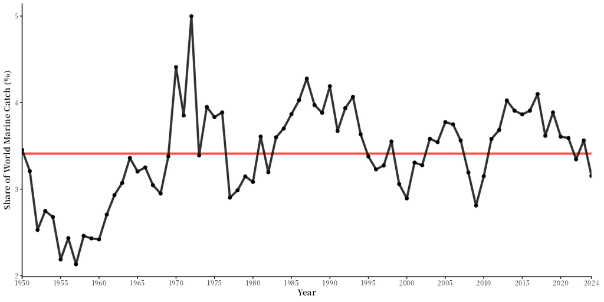

**`fishing_trend.png`: total catch and its stages**

🔎 *How to read it.* The grey area is the yearly catch of the area (million tonnes). The vertical dashed lines are **breakpoints**: years in which the mean catch changes, found with the Bai-Perron test (`strucchange::breakpoints()`); a stage starts at each dashed line. The horizontal grey segments are the mean catch of each stage.

*What it shows for area 67.* The catch rose from 0.6 million t in 1950 to a peak of 3.4 million t in 1987, and was 2.6 million t in 2024. The test finds 3 stages: 1950–1963 (mean 0.7 million t); 1964–1983 (mean 2.0 million t); 1984–2024 (mean 2.9 million t). They follow the history of the fleets, which the next steps show one by one: a small catch of salmon and herring by Canada and the United States in the 1950s; the arrival of the trawlers of the USSR and Japan, which fished the groundfish of the Bering Sea and the Gulf of Alaska from the 1960s; and, after the 200-mile fishery limits of 1977, the growth of the fleets of the United States to the high, steady catch of the last four decades.

**`fishing_percentage.png`: share of the world marine catch**

🔎 *How to read it.* Each point is the catch of the area as a percentage of the catch of all FAO marine areas in that year; the red line is the mean of these shares. Inland waters are not counted.

*What it shows for area 67.* The area took between 2.1% and 5.0% of the world marine catch, 3.4% on average, and 3.2% in 2024. A share above its mean means the area grew faster (or declined more slowly) than the rest of the world’s oceans: here in the 1980s, when its catch reached its plateau.

`NEP` is a list: `NEP$area_data` (the data of the area, used by all the next steps), `NEP$coefs_data` (the stages: first and last year and mean catch) and `NEP$act_world_map` (the map data). Save it with `saveRDS(NEP, "NEP.rds")` to continue later without recomputing.

## 4. 🐟 The main species

`fishing_area_species()` ranks the species items by their catch (`rank_range = 1:10`: the ten largest), draws their catch over time and finds the stages of each:

```r
sp <- fishing_area_species(area67, rank_range = 1:10)
```

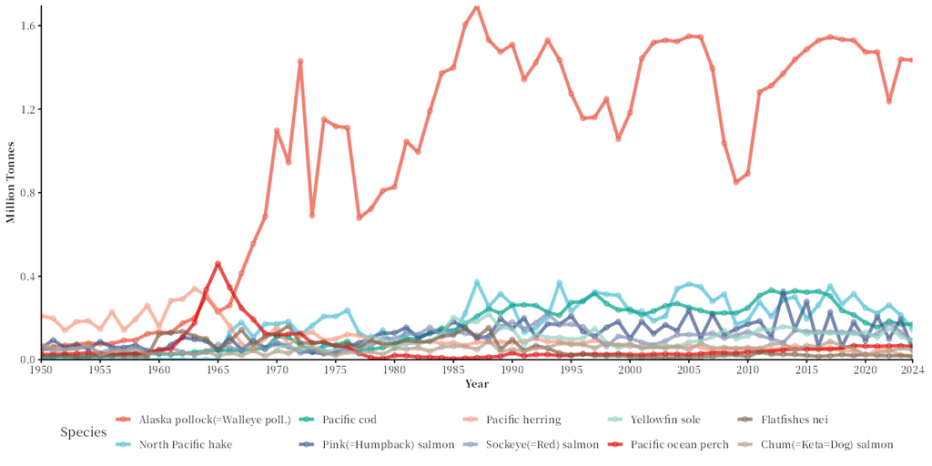

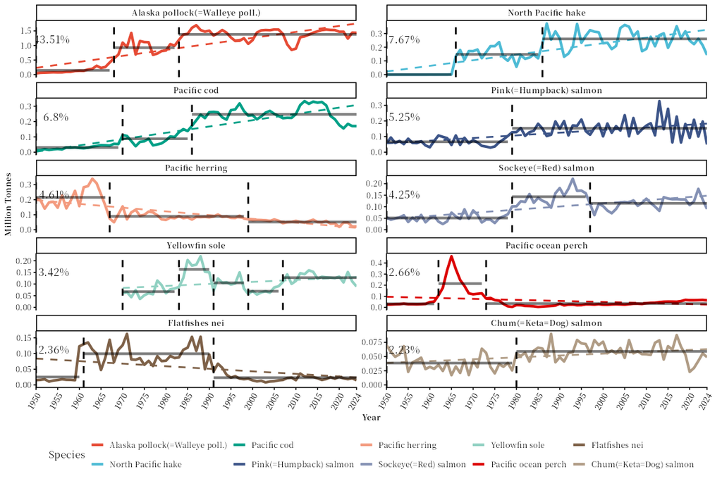

**`area_species.png`: the main species together**, and **`area_species_wrap.png`: one panel per species**

🔎 *How to read them.* The first chart puts the ten species items on one scale, to compare their size. The second gives each species its own panel and scale, so that small species are readable: the line is the yearly catch, the dashed vertical lines and grey segments are the stages of that species, the dashed slanted line is a linear trend, and the percentage is the share of the species in the catch of the area over all years.

*What it shows for area 67.* Over the last five years the largest items were Alaska pollock(=Walleye poll.) (1.41 million t a year), North Pacific hake (0.22 million t a year), Pacific cod (0.17 million t a year), Pink(=Humpback) salmon (0.13 million t a year), Sockeye(=Red) salmon (0.13 million t a year). Four patterns stand out:

- **One species dominates.** The Alaska pollock gave 43.5% of all the catch of the area since 1950, against 39.3% for the next nine items together. What happens to the pollock happens to the area.
- **Boom and bust.** The Pacific ocean perch, a rockfish, went from 0.03 million t in 1950 to a peak of 0.46 million t in 1965, taken mostly by Soviet and Japanese trawlers, and fell to 0.07 million t ten years later. Rockfishes grow slowly and live long, so they cannot sustain a heavy catch for long.
- **A fishery that faded.** The Pacific herring gave 0.21 million t in 1950 and peaked at 0.34 million t in 1963; its catch in 2024 was 0.022 million t.
- **Two-year cycles.** The pink salmon lives two years, so its runs alternate: since 2000 the catch averaged 0.21 million t in odd years and 0.11 million t in even years, the zigzag in its panel.

Changing `rank_range` changes the species shown, e.g. `rank_range = 11:20` for the next ten. The lines in the panels are smoothed only if `timeseries_analysis = FALSE`, which also removes the stages.

## 5. 🌎 The main countries

`fishing_area_country()` does the same for the countries, and adds a map of their catch:

```r
co <- fishing_area_country(area67, rank_range = 1:8)
```

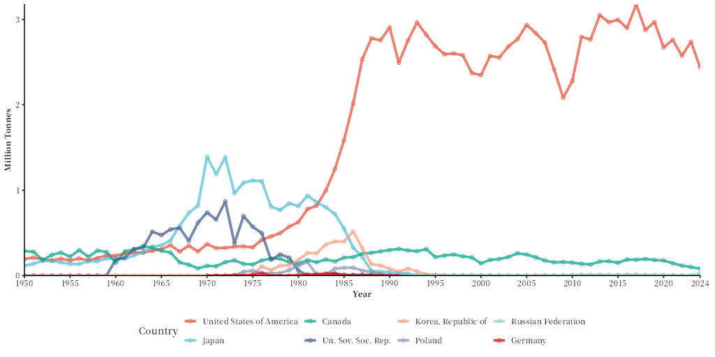

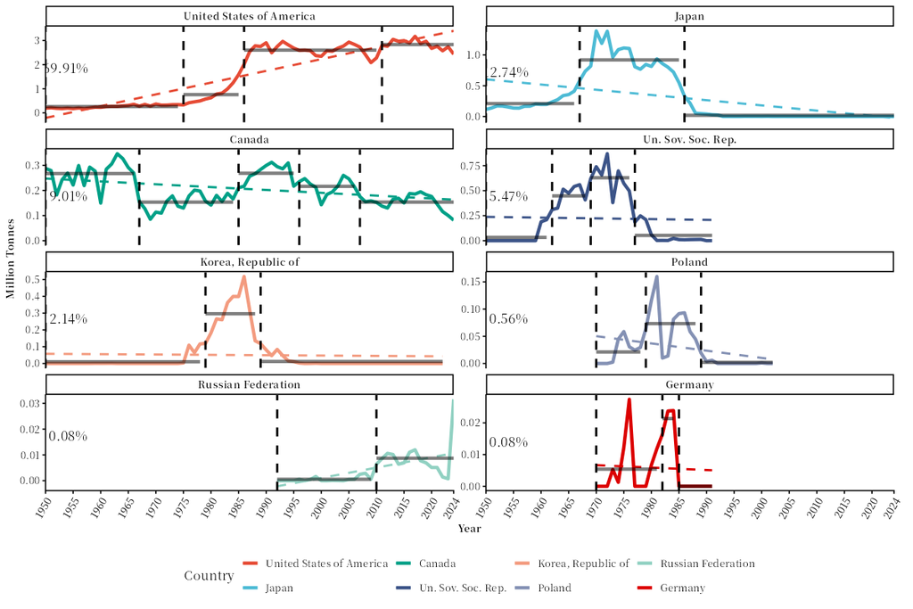

*What it shows for area 67.* Over the last five years, United States of America (95.2%) and Canada (4.5%) took almost all of the catch. It was not always so. **Canada** was the largest fishing country in 9 years of the 1950s; the **USSR** was the largest in 1962–1966 (its peak: 0.9 million t in 1972) and **Japan** in 1967–1982 (its peak: 1.4 million t in 1970); the **Republic of Korea** reached 0.5 million t in 1986. The share of the **United States** was only 14% in 1970 and 32% in 1980, then 87% in 1990 and 96% in 2024; it has caught more than Japan every year since 1983, and Japan’s last catch above 1 000 t in the area was in 2001.

This change has a clear cause. The Fishery Conservation and Management Act of the United States (1976, in force on 1 March 1977) created a 200-mile fishery zone and gave foreign fleets only the part of the catch that US fleets could not take; Canada extended its fishery limit to 200 miles in the same year. In the 1980s US fishing vessels first sold their catch to foreign processing ships at sea (“joint ventures”), then landed it at home, until foreign fishing ended. The panels of Japan, the USSR, Korea and Poland all end in those years.

## 6. 🔍 One species, one country

### 6.1 Who catches a species: `species_country()`

```r
pollock <- species_country(area67, "Alaska pollock(=Walleye poll.)", rank_range = 1:5)
```

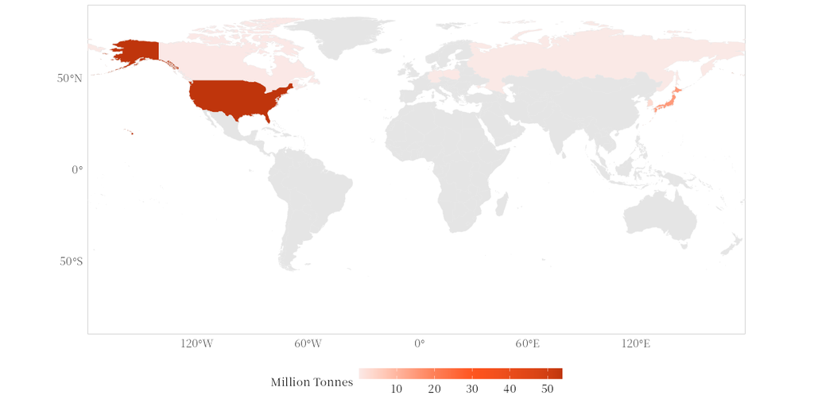

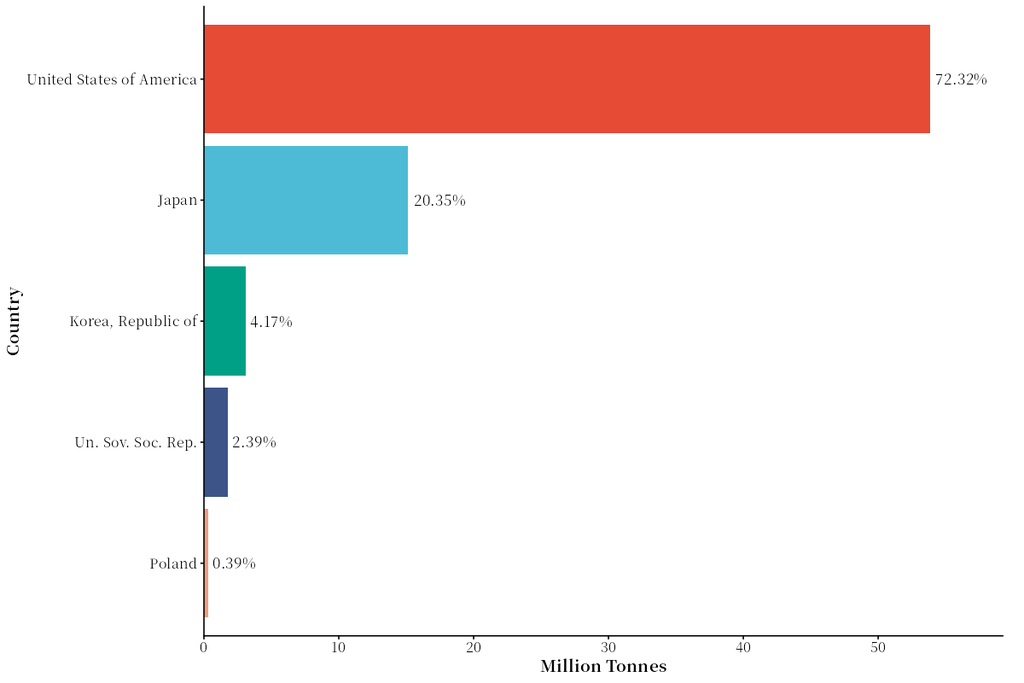

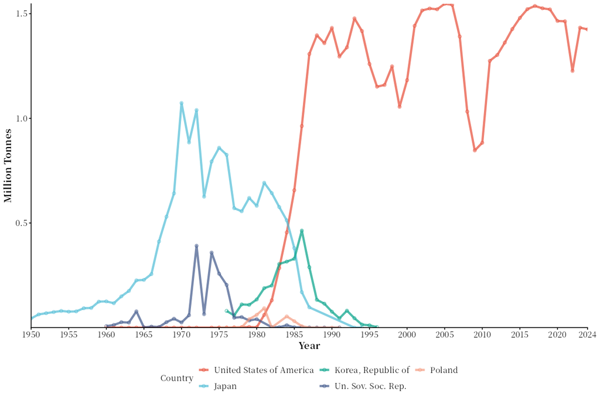

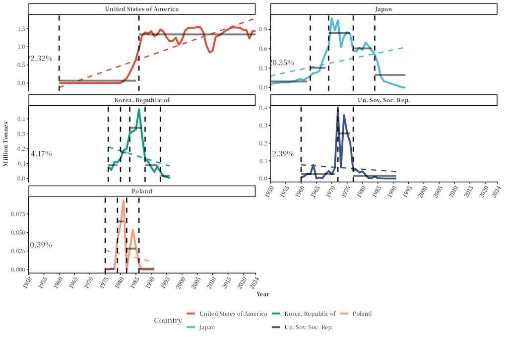

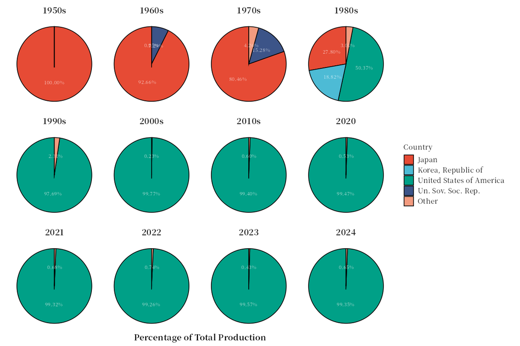

🔎 *How to read them.* The charts break the catch of one species item down by country: the ranked chart and the small multiples (one panel per country, with stages), a pie chart of the countries by period and a map. Species names must be written as in the FAO data (`unique(area67$ASFIS.species..Name.)` lists them; `fao_translate()` gives the Chinese names).

*What it shows for area 67.* The pollock story is the story of the area in miniature. Japan developed the fishery (peak 1.07 million t in 1970), followed by the USSR (peak 0.39 million t in 1972) and the Republic of Korea (peak 0.46 million t in 1986). The United States caught almost no pollock before 1980; its catch rose through the joint ventures of the 1980s and has been the only large one since, with a peak of 1.55 million t in 2005.

### 6.2 What a country catches: `country_species()` and `country_analysis()`

`country_species()` breaks down the catch of one country in the area by species; `country_analysis()` looks at the same country in **all** FAO areas, to see where it fishes:

```r
usa_67 <- country_species(area67, "United States of America", rank_range = 1:10)
usa_all <- country_analysis("United States of America", rank_range = 1:10)
```

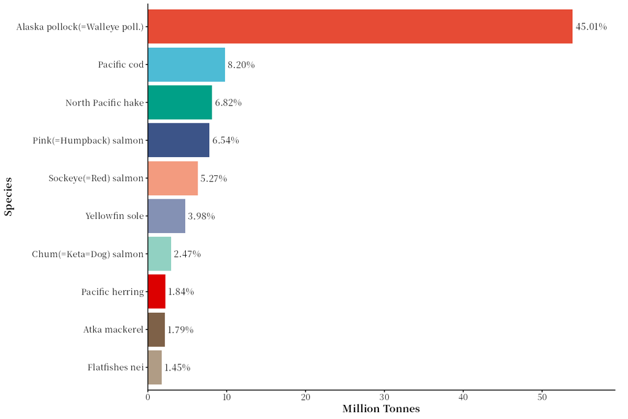

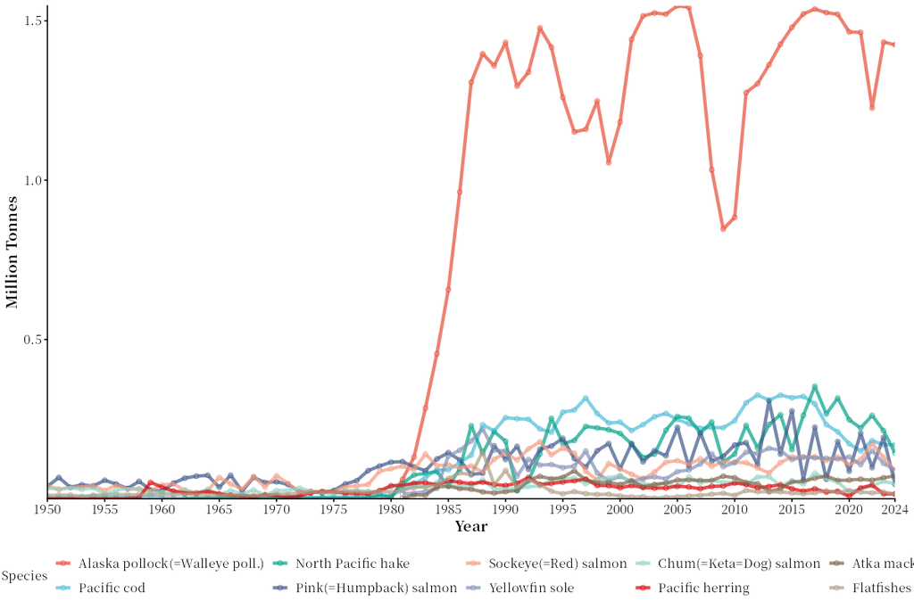

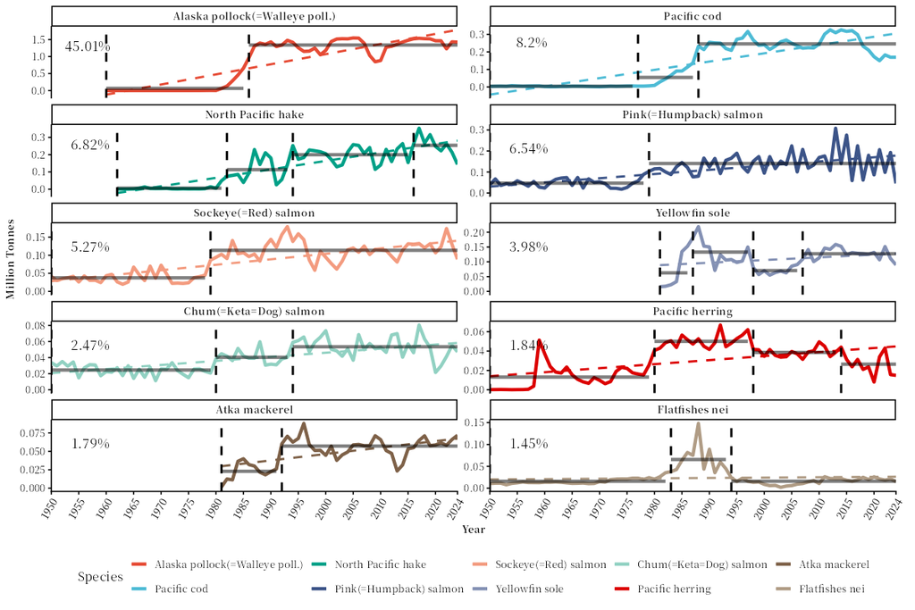

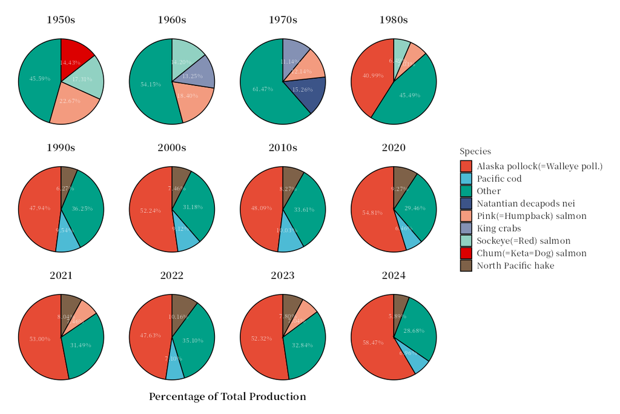

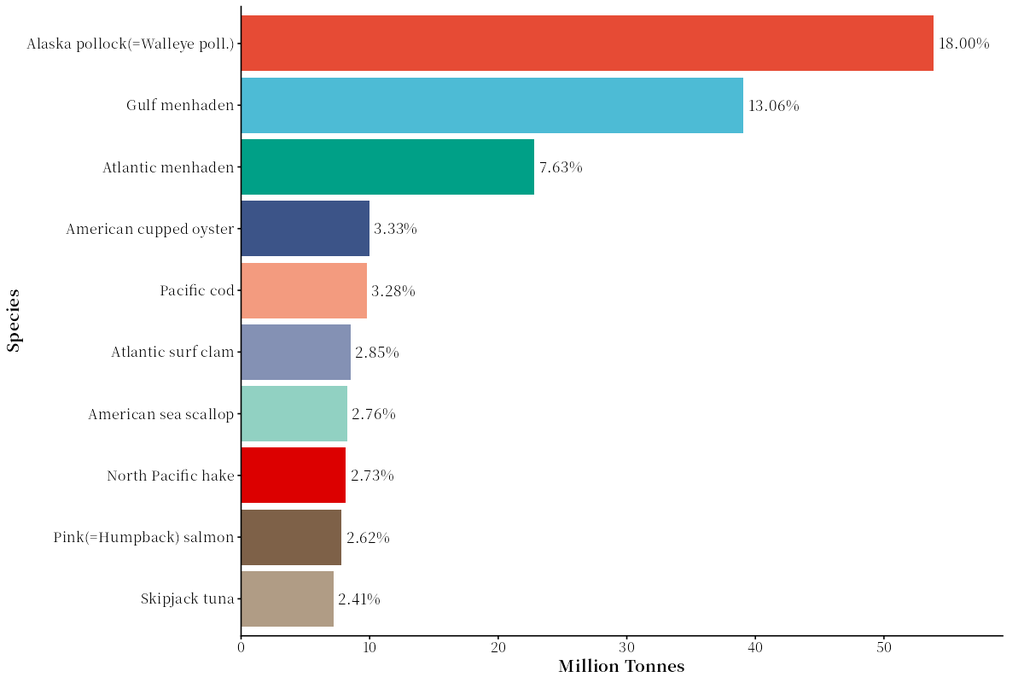

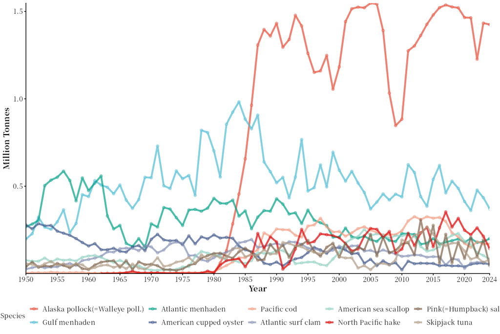

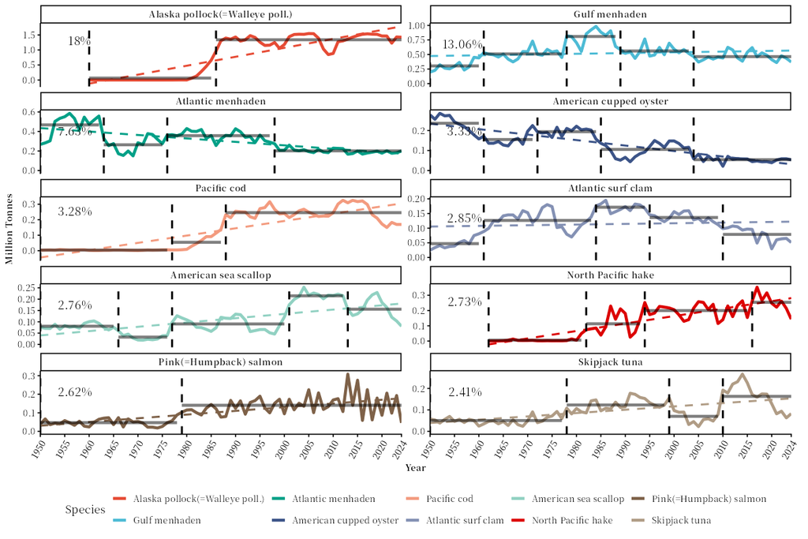

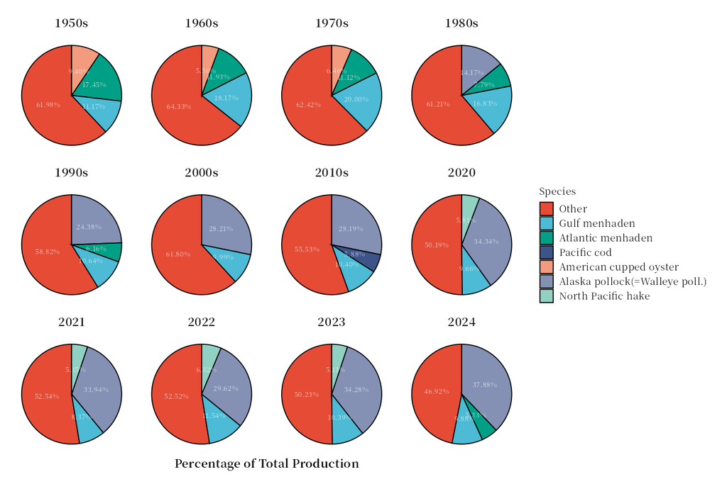

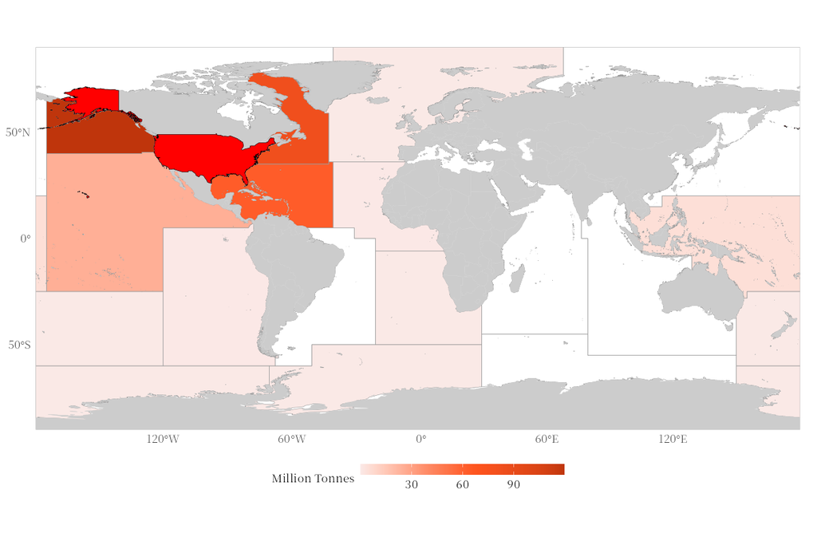

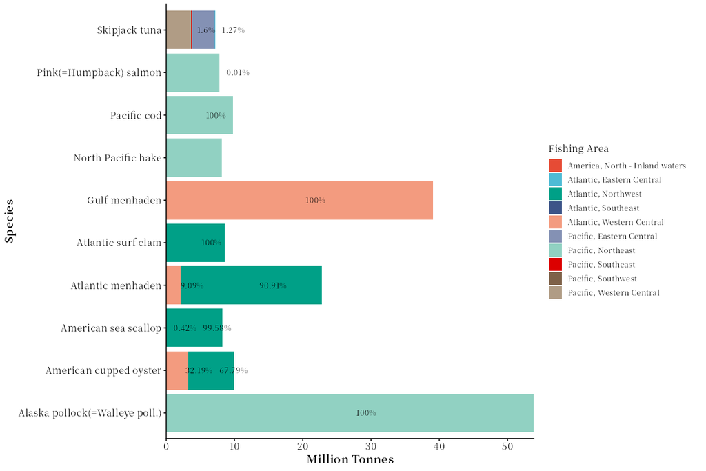

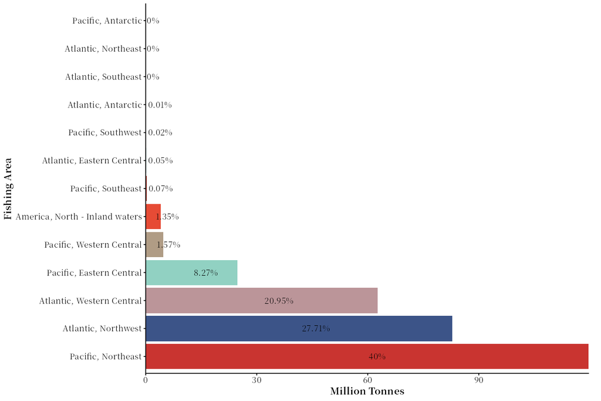

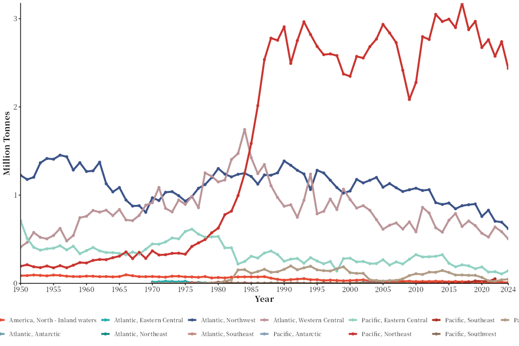

[1 more figures not shown]

🔎 *How to read them.* `United_States_of_America_species_*` charts: the species of the United States in area 67. `United_States_of_Americaanalysis_*` charts: the species of the United States in all areas, its catch by area (`United_States_of_Americayearly_area_production.png`, one line per area) and a map of the areas where it fishes.

*What it shows.* In the 1970s the US catch in area 67 was mostly Natantian decapods nei, Pink(=Humpback) salmon, King crabs: salmon, crabs and shrimps of the coastal fisheries. Over the last five years it was Alaska pollock(=Walleye poll.), North Pacific hake, Pacific cod: the groundfish that the foreign fleets had caught before. Across all FAO areas, area 67 has been the largest fishing area of the United States since 1985, when it passed the Northwest Atlantic; it now gives far more than all other areas.

## 7. 📈 Composition, stock status, trends and shifts

### 7.1 Species groups: `species_group_composition()`

```r
groups <- species_group_composition(area67)
```

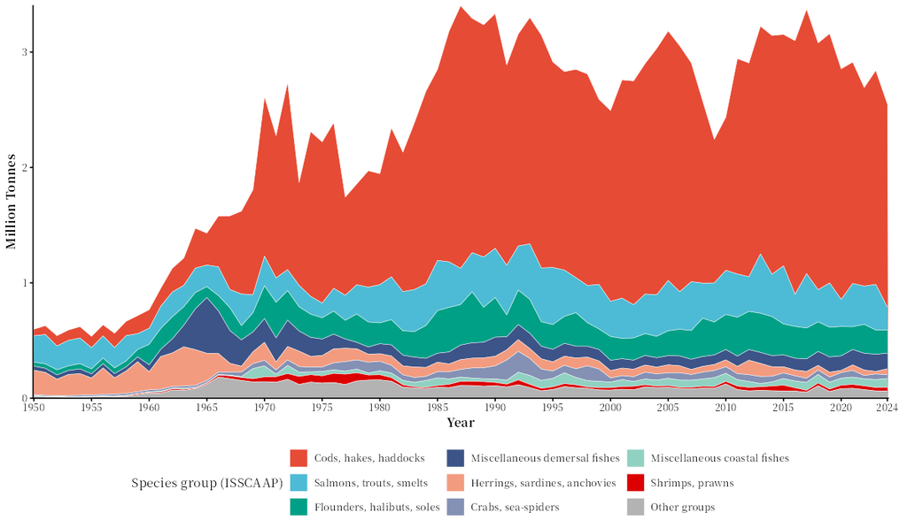

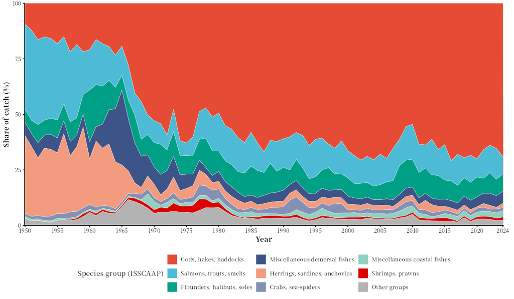

🔎 *How to read it.* Species items are grouped into the ISSCAAP groups of FAO (e.g. “Herrings, sardines, anchovies”, “Cods, hakes, haddocks”). The stacked areas show the catch of each group, and the `_share` chart its percentage of the catch; the largest groups are named, the others are “Other groups”.

*What it shows for area 67.* In 1950 the salmons (38%) and the herrings (35%) made up most of the catch, and the cods, hakes and haddocks only 9%. The trawl fisheries changed this within twenty years: the cods, hakes and haddocks (pollock, Pacific cod, Pacific hake) reached 53% in 1970 and 69% in 2024, with the flatfishes second.

### 7.2 Stock status plots: `stock_status()`

```r
status <- stock_status(area67)
```

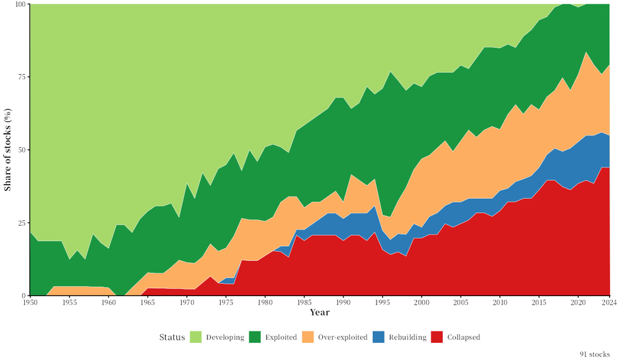

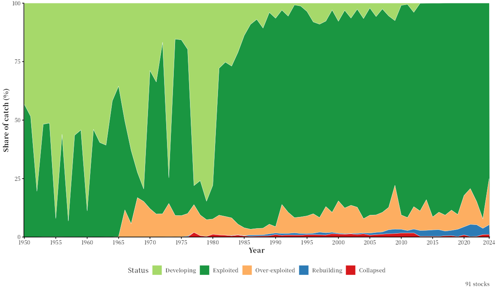

🔎 *How to read them.* Each “stock” is the catch series of one species item in the area. Every year, a stock is classed by its catch relative to its own peak (Kleisner et al. 2013): **developing** (before the peak, below half of it), **exploited** (above half of the peak), **over-exploited** (after the peak, 10–50% of it), **collapsed** (after the peak, below 10%) and **rebuilding** (back to 10–50% after a collapse). The `_stocks` chart counts stocks, the `_catch` chart weights them by their catch.

*What it shows for area 67.* Of the 91 stocks, in 2024 44.0% were collapsed and 24.2% over-exploited by number. Weighted by catch the picture is very different: the collapsed stocks took only 1.1% of the catch and the over-exploited ones 19.7%, while the exploited stocks, still above half of their peak, took 75.0%. Many small stocks are far below their old peaks (some of them, like the herring, because their fisheries were closed or not wanted any more), but the large stocks that give most of the catch are not.

**What not to conclude.** A stock status plot uses catch only. A fall in catch can come from fewer fish, but also from less fishing, management, markets or a change in reporting (e.g. a species reported as “nei”). Use it to ask questions, not as a stock assessment; `smooth = TRUE` classes the 3-year running mean, which reduces the effect of single bad years.

### 7.3 Peak and trend of each species: `peak_trend()`

```r
pt <- peak_trend(area67)
show_table(pt[, c("name", "peak_year", "pct_of_peak", "growth_pct_per_year", "trend")], n = 11)
```

[output not shown]

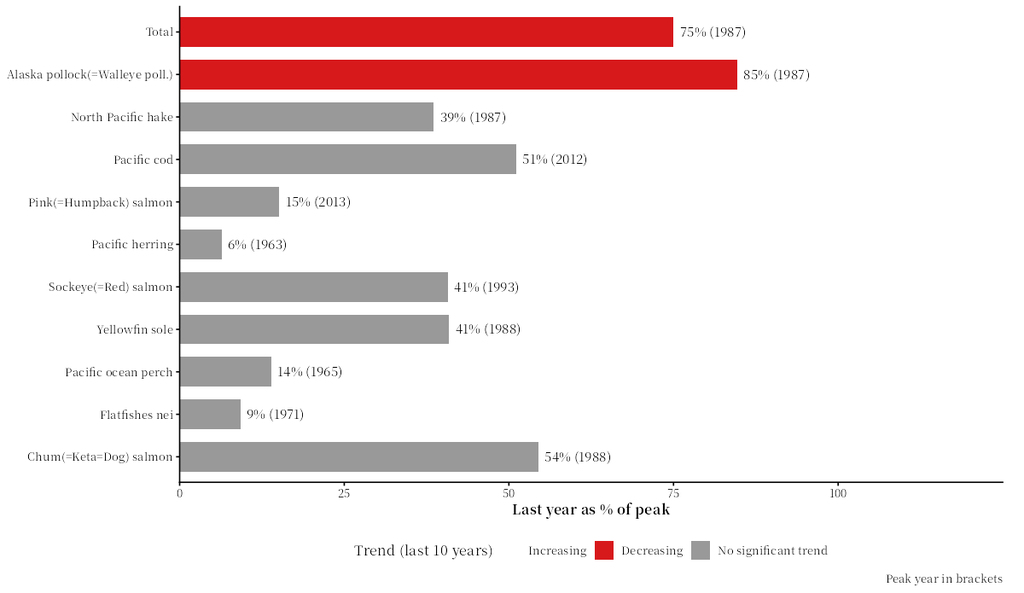

🔎 *How to read it.* For each of the main species: the year of its peak catch, the catch of the last year as a percentage of that peak, the mean yearly growth over the last ten years and the Mann-Kendall test of that trend (“up”, “down” or “none” at *P* < 0.05). In area 67 the total and the pollock are both close to their peak of the late 1980s, while the herring and the Pacific ocean perch are far below theirs.

### 7.4 Synchronous shifts: `regime_shift()`

```r
shifts <- regime_shift(area67)
```

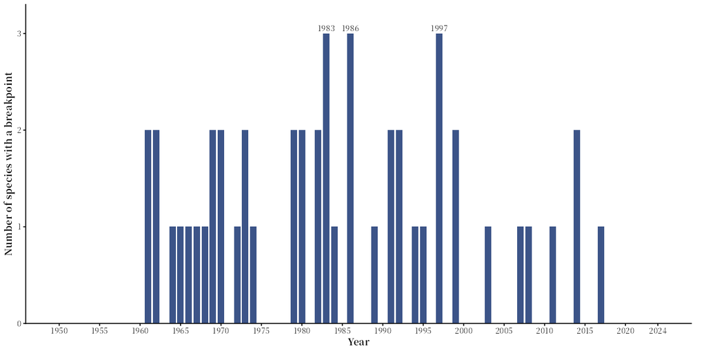

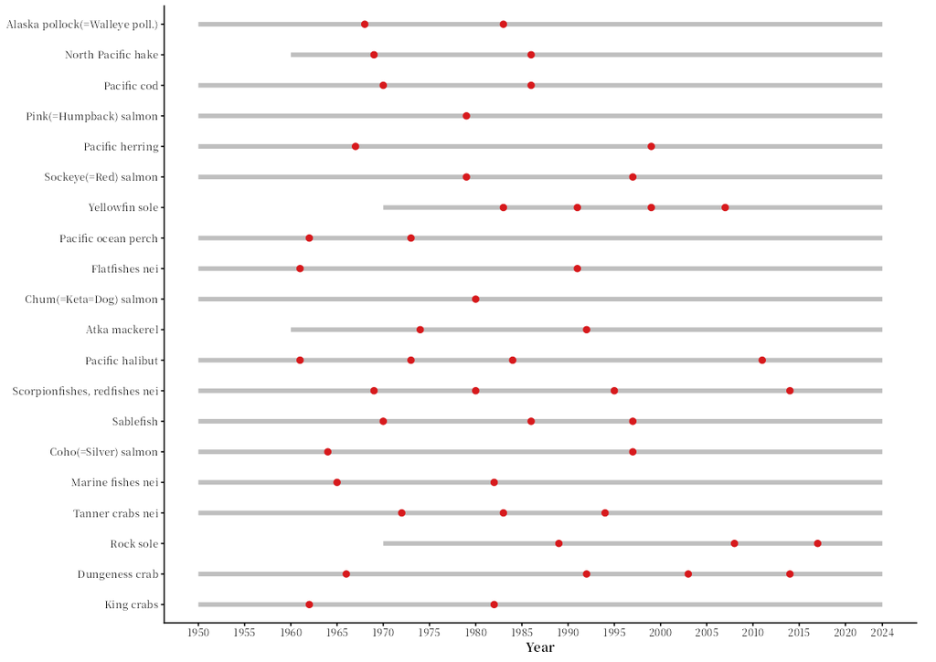

🔎 *How to read it.* The breakpoints of each main species are found as in step 4; the bar chart counts, for every year, how many species changed their mean catch in that year. Years when many species change together point to a common cause: the ocean (a regime shift), a change of management, or a change of reporting.

*What it shows for area 67.* The years with the most simultaneous breakpoints are 1983 (3 species), 1986 (3 species), 1997 (3 species). The North Pacific had well-known climate regime shifts in 1977 and 1989 (Hare and Mantua 2000), but the catch breakpoints cluster instead in the 1980s, the years when the catch passed from foreign to US fleets. In catch data, fleets and management often leave a larger mark than the ocean; a breakpoint alone cannot tell which cause it was.

### 7.5 All FAO areas compared: `area_overview()`

```r
overview <- area_overview()
```

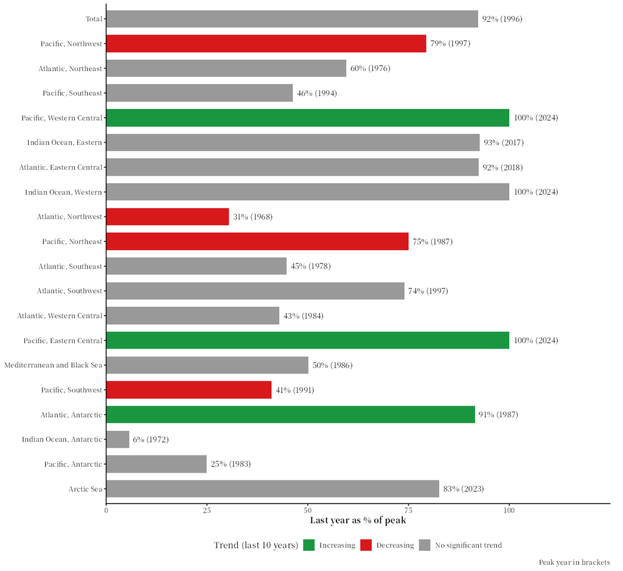

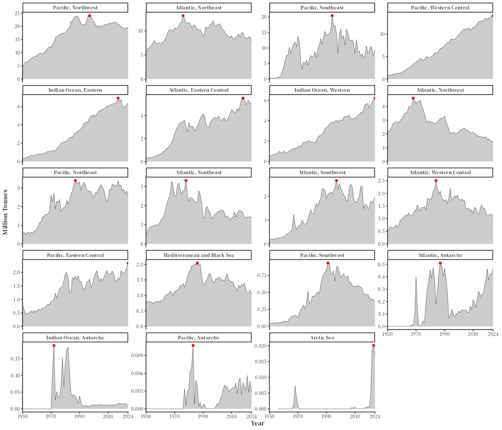